# Tidybiology Final Project

Anvita Kulshrestha

November 05, 2023

## Load libraries, such as tidyverse and tidybiology

```r
library(tidyverse)
library(readr)
#uncomment (or select) to clear environment; good for provenance
rm(list=ls())
```

## Import data

We are interested in exploring gene expression profiles from 7 different tissue types. This data is a subset of the data provided by the ‘tissuesGeneExpression’ package available from the ‘genomicsclass’ Github repository.

```r
tissue_gene_expression <- read_csv("~/Downloads/tissue_gene_expression.csv")
dim(tissue_gene_expression) #there are 189 rows and 502 columns
```

```
## [1] 189 502
```

```r
#We would like to move the last column ("y") right after the first column since it is telling us about the tissue type. We would also like to rename the "rownames" and "y" columns to make them more informative.

colnames(tissue_gene_expression) <- c("tissue", colnames(tissue_gene_expression)[2:502])
tissue_gene_expression <- select(tissue_gene_expression, tissue, y, everything())
colnames(tissue_gene_expression) <- c("tissue", "tissue_type", colnames(tissue_gene_expression)[3:502])
```

## Take a `glimpse` into the data in the dataframe

This data frame contains gene expression values for 500 genes in 7 different tissue types (total of 189 tissues). Each row is a gene expression profile from a tissue sample and each column is a different gene.

```r
glimpse(tissue_gene_expression)
```

```
## Rows: 189
## Columns: 502
## $ tissue         <chr> "cerebellum_1", "cerebellum_2", "cerebellum_3", "cerebe…
## $ tissue_type    <chr> "cerebellum", "cerebellum", "cerebellum", "cerebellum",…
## $ x.MAML1        <dbl> 9.825680, 9.631247, 9.690548, 9.991592, 9.578130, 9.860…
## $ x.LHPP         <dbl> 8.327163, 8.542827, 8.476486, 8.506430, 8.371783, 8.278…
## $ x.SEPT10       <dbl> 5.499382, 5.644292, 5.717187, 5.789430, 5.779698, 5.718…
## $ x.B3GNT4       <dbl> 8.692371, 8.833679, 8.498623, 8.421143, 8.818455, 8.728…
## $ x.ZNF280D      <dbl> 5.642305, 5.685083, 5.958232, 5.736563, 5.630886, 5.708…
## $ x.SOX12        <dbl> 6.254751, 6.289460, 6.215924, 6.512055, 6.201556, 6.367…
## $ x.C21orf62     <dbl> 5.840938, 6.065646, 5.771117, 5.851617, 5.965732, 5.769…
## $ x.PER3         <dbl> 8.330565, 8.263576, 9.102294, 9.210058, 8.502172, 8.766…
## $ x.HOXA10       <dbl> 5.520803, 5.528077, 5.599405, 5.561197, 5.601099, 5.681…
## $ x.HOXC5        <dbl> 7.660495, 7.569041, 7.418460, 7.332254, 7.535668, 7.535…
## $ x.BLVRB        <dbl> 7.669237, 7.779377, 7.552049, 7.839703, 7.598154, 7.720…
```

[output cut: 489 more lines]

```r
#what tissue types are represented in this data set?
unique(tissue_gene_expression$tissue_type)
```

```
## [1] "cerebellum"  "colon"       "endometrium" "hippocampus" "kidney"
## [6] "liver"       "placenta"
```

## EDA

Taking a glimpse at the data, we find many genes that are involved in several cellular and molecular processes that have been associated with different cancer types. Let us look at some of the genes in the Zinc-finger protein (ZNF) family. ZNFs play an important role in development and differentiation of several tissues. As a result, their dysregulation is implicated in tumorigenesis, cancer progression and metastasis formation. We are interested in looking at the gene expression profiles of ZNF genes in different tissues.

```r
#subset the data to get the genes of interest
genes_subset <- tissue_gene_expression[, grepl("x.ZNF|tissue", names(tissue_gene_expression))]

#In order to compare gene expression values across tissue types, we will calculate the average gene expression for each tissue type.

average_expression <- genes_subset %>%
  group_by(tissue_type) %>%
  summarize_at(c(2:15), list(average = mean))

glimpse(average_expression)
```

```
## Rows: 7
## Columns: 15
## $ tissue_type          <chr> "cerebellum", "colon", "endometrium", "hippocampu…
## $ x.ZNF280D_average    <dbl> 5.780479, 5.257236, 5.762917, 5.704043, 5.333309,…
## $ x.ZNF552_average     <dbl> 6.997173, 7.558453, 7.600688, 6.987170, 7.440032,…
## $ x.ZNF529_average     <dbl> 7.211634, 5.163939, 5.404791, 6.838831, 5.260721,…
## $ x.ZNF135_average     <dbl> 5.338316, 4.927900, 5.258554, 5.240570, 5.080718,…
## $ x.ZNF274_average     <dbl> 8.507992, 7.871981, 8.116007, 8.104399, 8.388179,…
## $ x.ZNF587B_average    <dbl> 6.372111, 6.691381, 6.323457, 6.088920, 6.637015,…
## $ x.ZNF213.AS1_average <dbl> 6.543848, 6.644740, 6.332327, 6.570478, 6.441928,…
## $ x.ZNF768_average     <dbl> 7.119308, 7.074101, 7.163435, 6.905429, 7.357524,…
## $ x.ZNF304_average     <dbl> 6.588509, 5.347657, 5.835164, 6.589786, 5.780040,…
## $ x.ZNF354A_average    <dbl> 5.976010, 5.977348, 6.001330, 6.343558, 6.063483,…
## $ x.ZNF711_average     <dbl> 4.860617, 4.578466, 4.625456, 4.699781, 4.592830,…
## $ x.ZNF43_average      <dbl> 5.665246, 5.449131, 5.671236, 5.714182, 5.557010,…
## $ x.ZNF45_average      <dbl> 5.049686, 4.850469, 5.107773, 4.728597, 5.014640,…
## $ x.ZNF767P_average    <dbl> 8.524094, 7.430176, 7.239721, 7.984273, 7.371349,…
```

## EDA Graph

Let us take an example of ZNF529 gene and look at its expression across all the tissues sampled.

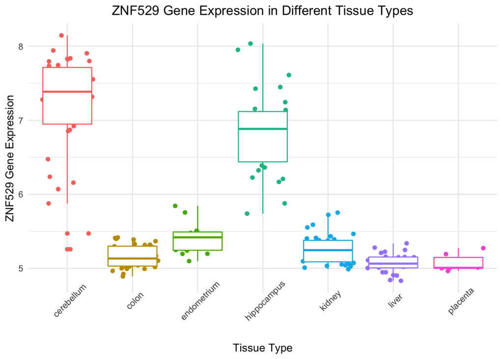

```r
#The gene expression profiles are represented as log2-microarray measurements.
genes_subset %>%
  group_by(tissue_type) %>%
  ggplot(aes(x = tissue_type, y = x.ZNF529)) +
  geom_jitter(aes(color = tissue_type)) +
  geom_boxplot(aes(color = tissue_type)) +
  theme_minimal() +
  labs(x = "Tissue Type",
       y = "ZNF529 Gene Expression",
       title = "ZNF529 Gene Expression in Different Tissue Types") +
  theme(legend.position = "none", axis.text.x = element_text(angle = 45), plot.title = element_text(hjust = 0.5))
```

## Final Graph

Looking at the above box-plot, it is clear that ZNF529 has higher expression in cerebellum and hippocampus which may hint towards its functional role in nervous system. These results are consistent with the current literature. In order to better understand the expression profile of ZNF genes, we will take a look at the expression of all ZNF genes in this data set across different tissue types.

```r
#creating a new data frame with average expression of genes across different tissue types
genes_subset_new <- genes_subset %>% select(-tissue)
genes_subset_means <- genes_subset_new %>%
  pivot_longer(-tissue_type, names_to = "Gene", values_to = "Expression") %>%  # Reshape the data
  group_by(tissue_type, Gene) %>%  # Group by tissue type and gene
  summarize(Mean_Expression = mean(Expression))
```

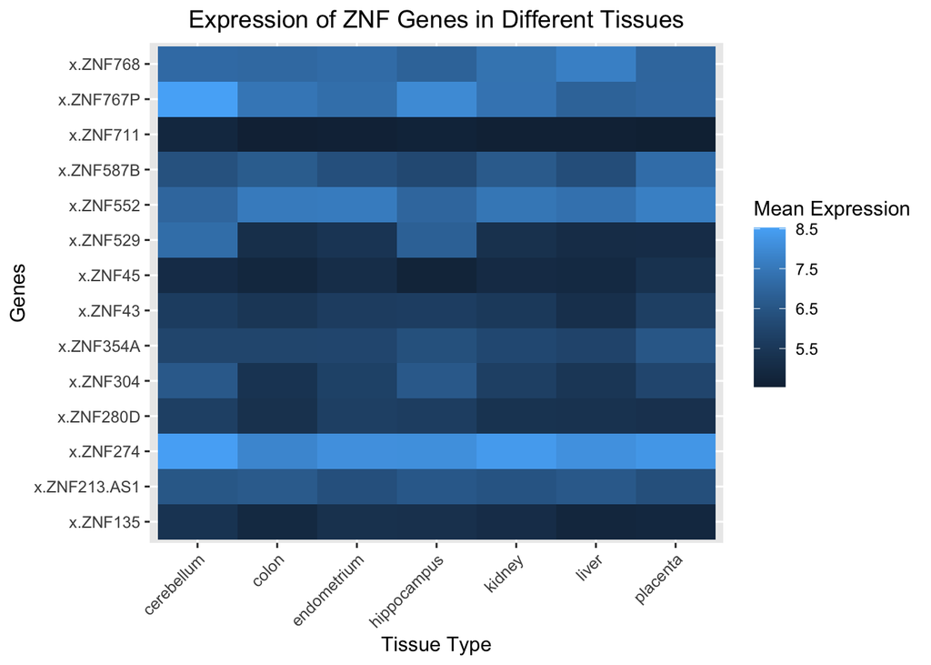

```r
#visualizing the data using a heatmap
genes_subset_means %>%
  ggplot(aes(x = tissue_type, y = Gene, fill = Mean_Expression)) +
  geom_tile() +
  labs(x = "Tissue Type",
       y = "Genes",
       title = "Expression of ZNF Genes in Different Tissues",
       fill = "Mean Expression") +
  theme(axis.text.x = element_text(angle = 45, hjust = 1), plot.title = element_text(hjust = 0.5))
```

## Conclusions

From the plots shown above, we observe that some of the ZNF genes have tissue-specific expression (eg. ZNF529) where they are highly expressed in some tissues but not all. At the same time, there are some ZNF genes that are highly expressed in all tissue types studied (like ZNF274) while others are expressed at a low level in all tissues (like ZNF711). In all, ZNF genes that have tissue-specific expression may contribute to a specific function in those tissues whereas others may be broadly involved in tissue development and differentiation.

## Prioritized follow-up studies

For future studies, we are interested in looking at genes that have tissue-specific expression (referred here as candidate genes). Conducting functional analysis (using knockout or knockdown experiments) would be useful to study the effects of these candidate genes on specific tissues. Furthermore, gene regulation studies would be instrumental in investigating the regulatory mechanisms behind tissue-specific gene expression, linking expression profiles to biological pathways.

## Acknolwedgements

I would like to thank the instructors, Dr. Hirschey, Dr. Bareja, and Telmo for the amazing module. :)

```r
#You can remove an item from sessionInfo(), which is a list with a class attribute, by printing the resulting object omitting one of the list items (omitted list of packages installed, but not loaded)
```